# Data summary

Carlos S Traynor

05/10/2018

## Data charecterisation

Here we summarise the general features of the lung squamos cell (LUSC) and colon adenocarcinoma (COAD) TCGA datasets. The data have been downloaded from TCGA and the CBioPortal following these links: LUSC: http://www.cbioportal.org/study?id=lusc_tcga#clinical COAD: http://www.cbioportal.org/study?id=coadread_tcga#summary

We will use the following libraries:

```r
if(!require("devtools")) install.packages("devtools")
if(!require("tidyprojectAZ")) devtools::install_github("tsahota/tidyprojectAZ")
library(tidyprojectAZ)
```

## Colorectal adenocarcinoma

First we will load the data and make a basic preprocess, to include later the genomic covariates in the model we will filter the clinical dataset for those individuals that also have genomic measurements:

```r
coad_clinical <- "~/test-data/coadread_tcga/data_bcr_clinical_data_patient.txt"
convert_blank_to_na <- function(x) {
    if (!purrr::is_character(x)) {
        return(x)
        print("Error not character")
    } else {
        ifelse(x == "" | x == "[Not Available]" | x == "--" | x ==
            "not reported" | x == "[Not Applicable]" | x == "[Discrepancy]",
            NA, x)
    }
}
preprocess_clinical <- function(file) {
    clinical_data <- readr::read_tsv(file, skip = 4)
    # convert variable names to lower case
    colnames(clinical_data) <- tolower(colnames(clinical_data))
    # convert all string NA to NA format
    clinical_data <- clinical_data %>% dplyr::mutate_all(dplyr::funs(convert_blank_to_na))
    clinical_data
}

coad_clinical <- preprocess_clinical(coad_clinical)
## Load patient id all
match_remove_is_na <- function(x, y) {
    match(x, y)[!is.na(match(x, y))]
}
patient_id <- readRDS("~/iClusterPlusUtils/coad/coad_complete_patient_id.RDS")
coad_clinical <- coad_clinical[match_remove_is_na(patient_id, coad_clinical$patient_id),
    ]
dplyr::glimpse(coad_clinical)
```

```
## Observations: 301
## Variables: 64
## $ other_patient_id                        <chr> "A94E1279-A975-480A-93...
## $ patient_id                              <chr> "TCGA-3L-AA1B", "TCGA-...
## $ form_completion_date                    <chr> "4/22/14", "10/1/14", ...
## $ histological_diagnosis                  <chr> "Colon Adenocarcinoma"...
## $ prospective_collection                  <chr> "YES", "YES", "NO", "N...
## $ retrospective_collection                <chr> "NO", "NO", "YES", "YE...
## $ sex                                     <chr> "Female", "Male", "Fem...
## $ days_to_birth                           <chr> "-22379", "-24523", "-...
## $ race                                    <chr> "BLACK OR AFRICAN AMER...
## $ ethnicity                               <chr> "NOT HISPANIC OR LATIN...
## $ history_other_malignancy                <chr> NA, "No", "No", "No", ...
## $ history_neoadjuvant_trtyn               <chr> "No", "No", "No", "No"...
## $ initial_pathologic_dx_year              <int> 2013, 2013, 2013, 2009...
```

[output cut: 51 more lines]

In the tidy description of the dataset obtained with glimpse we see that we have covariates that may potentially be used as treatment effect:

- pharmaceutical_tx_adjuvant
- radiation_treatment_adjuvan
- history_neoadjuvant_trtyn

Then we have variables that may be considered secondary outcome and potentially joint modelled with the overall survival:

- treatment_outcome_first_course
- new_tumor_event_after_initial_treatment
- dfs_status
- dfs_months

We can visualise the missing values of these variables with the VIM package:

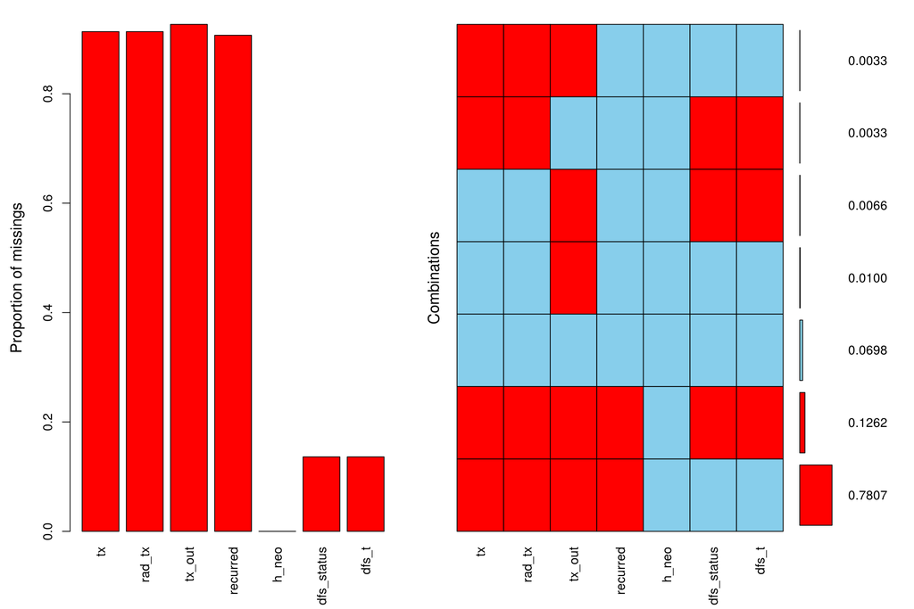

```r
coad_clinical %>% dplyr::select(tx = pharmaceutical_tx_adjuvant,
    rad_tx = radiation_treatment_adjuvant, tx_out = treatment_outcome_first_course,
    recurred = new_tumor_event_after_initial_treatment, h_neo = history_neoadjuvant_trtyn,
    dfs_status, dfs_t = dfs_months) %>% VIM::aggr(prop = T, labels = colnames(.),
    numbers = TRUE)
```

Unfortunately we might have too many missing values of treatment effects and secondary endpoints to include most of these variables in the model. On the other hand we have history_neoadjuvant_trtyn as potential, let’s explore this variable with a table:

```r
knitr::kable( table(coad_clinical$history_neoadjuvant_trtyn, useNA = "ifany") )
```

| Var1 | Freq |
| --- | --- |
| No | 301 |

However, the problem might seem that the variability of history variable is too low.

The dataset also includes interesting genomic variables such as kras or braf status:

```r
knitr::kable( table(coad_clinical$kras_mutation, coad_clinical$braf_gene_analysis_result, useNA = "ifany") )
```

|  | Abnormal | Normal | NA |
| --- | --- | --- | --- |
| NO | 1 | 13 | 12 |
| YES | 0 | 13 | 11 |
| NA | 2 | 1 | 248 |

This table shows again that too many are missing values, what is more the NAs are not informative, i.e. we can’t assume that NA means that the value is normal but intstead it means that the test was not carried out.

Still we can use a few clinical variables:

- age
- weight
- stage

They might be correlated with both dfs and os in an experiment joint model. Let’s visualise the missing values for these variables:

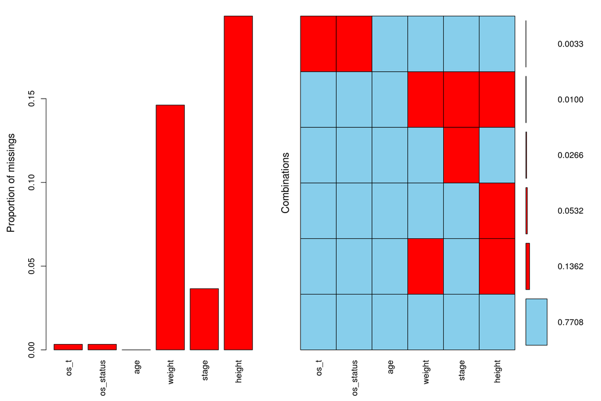

```r
coad_clinical %>%
  dplyr::select(os_t = os_months, os_status, age, weight, stage = ajcc_pathologic_tumor_stage, height ) %>%
  VIM::aggr(prop = T, labels = colnames(.), numbers = TRUE)
```

Still weight and height are missing in an important proportion of subjects, around 0.15, however, we could run two separate analysis with complete cases and imputations and contrast the inferences of each model.

Let’s now have a look at the primary and secondary endpoints:

- overall survival.
- disease free survival.

We make an explanatory table with the survival package of the overall survival:

```r
require(survival)
(s1 <- survfit(Surv(os_months, os_status) ~ 1, data = coad_clinical %>%
          dplyr::mutate(os_months = as.numeric(os_months),
                        os_status = os_status == "DECEASED")))
```

```
## Call: survfit(formula = Surv(os_months, os_status) ~ 1, data = coad_clinical %>%
##     dplyr::mutate(os_months = as.numeric(os_months), os_status = os_status ==
##         "DECEASED"))
##
##    1 observation deleted due to missingness
##       n  events  median 0.95LCL 0.95UCL
##   300.0    67.0    83.2    60.7      NA
```

We may graph the os Kaplan and Meier plots using the package survminer:

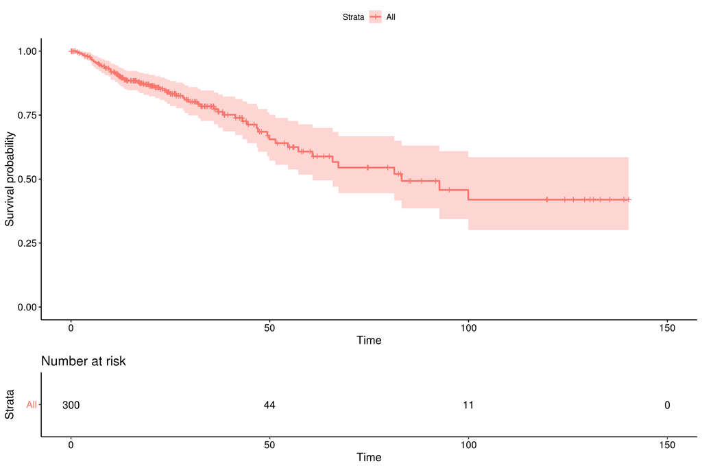

```r
survminer::ggsurvplot(fit = s1, risk.table = TRUE )
```

We can similarly do for dfs:

```r
(s2 <- survfit(Surv(dfs_months, dfs_status) ~ 1, data = coad_clinical %>%
    dplyr::mutate(dfs_months = as.numeric(dfs_months), dfs_status = dfs_status ==
        "Recurred/Progressed")))
```

```
## Call: survfit(formula = Surv(dfs_months, dfs_status) ~ 1, data = coad_clinical %>%
##     dplyr::mutate(dfs_months = as.numeric(dfs_months), dfs_status = dfs_status ==
##         "Recurred/Progressed"))
##
##    41 observations deleted due to missingness
##       n  events  median 0.95LCL 0.95UCL
##   260.0    67.0    74.6    63.1      NA
```

And the dfs KM plot:

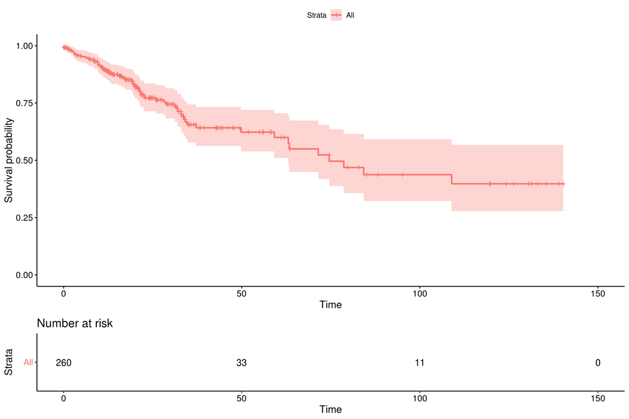

```r
survminer::ggsurvplot(fit = s2, risk.table = TRUE )
```

Actually, here we can see that n for dfs is smaller 300 to 260. We’ll start exploring how these two outcomes might be related with the following table:

```r
(s3 <- survfit(Surv(os_months, os_status) ~ dfs_status, data = coad_clinical %>%
    dplyr::mutate(os_months = as.numeric(os_months), os_status = os_status ==
        "DECEASED")))
```

```
## Call: survfit(formula = Surv(os_months, os_status) ~ dfs_status, data = coad_clinical %>%
##     dplyr::mutate(os_months = as.numeric(os_months), os_status = os_status ==
##         "DECEASED"))
##
##    41 observations deleted due to missingness
##                                  n events median 0.95LCL 0.95UCL
## dfs_status=DiseaseFree         193      0     NA      NA      NA
## dfs_status=Recurred/Progressed  67     27   65.8    43.2      NA
```

We found that in the Disease Free subgroup there are no deaths recorded. This is suspicious of informative censoring, deaths might ocurre before dfs is recorded. We could account for this in our analysis by using a simple assumption: os_deceased equivals to right censoring for dfs.

```r
(s4 <- survfit(Surv(os_months, os_status) ~ dfs_status, data = coad_clinical %>%
    dplyr::mutate(os_months = as.numeric(os_months), os_status = os_status ==
        "DECEASED", dfs_status = ifelse(is.na(dfs_status), "DiseaseFree",
        dfs_status))))
```

```
## Call: survfit(formula = Surv(os_months, os_status) ~ dfs_status, data = coad_clinical %>%
##     dplyr::mutate(os_months = as.numeric(os_months), os_status = os_status ==
##         "DECEASED", dfs_status = ifelse(is.na(dfs_status), "DiseaseFree",
##         dfs_status)))
##
##    1 observation deleted due to missingness
##                                  n events median 0.95LCL 0.95UCL
## dfs_status=DiseaseFree         233     40     NA    60.7      NA
## dfs_status=Recurred/Progressed  67     27   65.8    43.2      NA
```

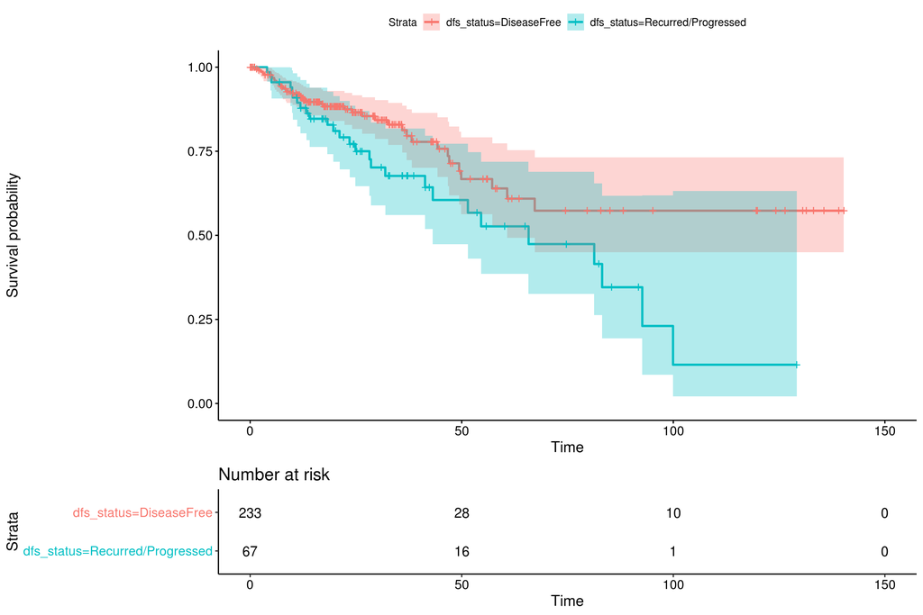

```r
survminer::ggsurvplot(fit = s4, risk.table = TRUE, conf.int = TRUE )
```

## Lung squamous cell carcinoma (LUSC)

We move now to the LUSC dataset we are basically goin to go through a similar explanatory process, first step load the data:

```r
lusc_clinical <- "~/test-data/lusc/data_bcr_clinical_data_patient.txt"
lusc_clinical <- preprocess_clinical(lusc_clinical)
patient_id <- readRDS("~/iClusterPlusUtils/lusc/lusc_complete_patient_id.RDS")
lusc_clinical <- lusc_clinical[match_remove_is_na(patient_id, lusc_clinical$patient_id), ]
dplyr::glimpse(lusc_clinical)
```

```
## Observations: 367
## Variables: 83
## $ other_patient_id                           <chr> "e28cbc9a-aa60-4bfb...
## $ patient_id                                 <chr> "TCGA-18-3417", "TC...
## $ form_completion_date                       <chr> "3/25/11", "4/4/11"...
## $ histological_diagnosis                     <chr> "Lung Squamous Cell...
## $ prospective_collection                     <chr> "NO", "NO", "NO", "...
## $ retrospective_collection                   <chr> "YES", "YES", "YES"...
## $ sex                                        <chr> "Male", "Male", "Ma...
## $ race                                       <chr> NA, "WHITE", NA, NA...
## $ ethnicity                                  <chr> NA, "NOT HISPANIC O...
## $ laterality                                 <lgl> NA, NA, NA, NA, NA,...
## $ history_other_malignancy                   <chr> "No", "No", "No", "...
## $ primary_site                               <chr> "R-Upper", "L-Lower...
## $ location_lung_parenchyma                   <chr> NA, NA, NA, NA, NA,...
```

[output cut: 70 more lines]

In this dataset we may potentially also use treatment effects, ecog score, or also secondary outcomes:

- karnofsky_performance_score
- ecog_score
- radiation_treatment_adjuvant
- pharmaceutical_tx_adjuvant
- tumor_status
- dfs_status
- dfs_months

We can visualise the missing values of these variables with the VIM package:

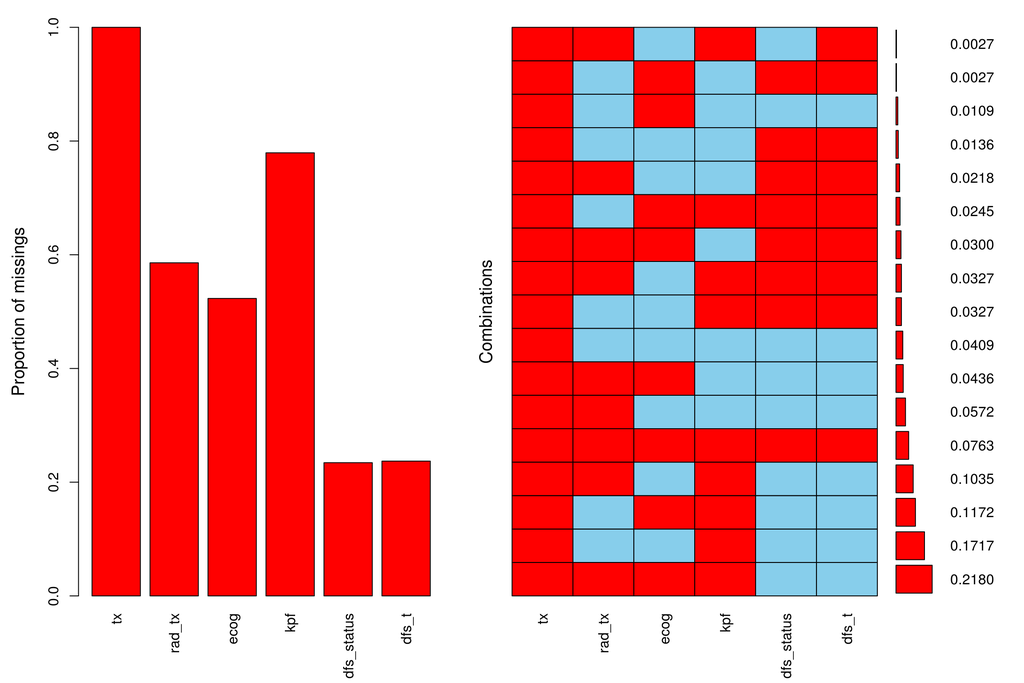

```r
lusc_clinical %>% dplyr::select(tx = pharmaceutical_tx_adjuvant,
    rad_tx = radiation_treatment_adjuvant, ecog = ecog_score, kpf = karnofsky_performance_score,
    dfs_status, dfs_t = dfs_months) %>% VIM::aggr(prop = T, labels = colnames(.),
    numbers = TRUE)
```

Among all the potential variables we might be able to use ecog, but with difficulty because it has a proportion of 0.5 missing values.

We can also consider the following clinical variables:

- age
- ajcc_pathologic_tumor_stage
- tobacco_smoking_history_indicator

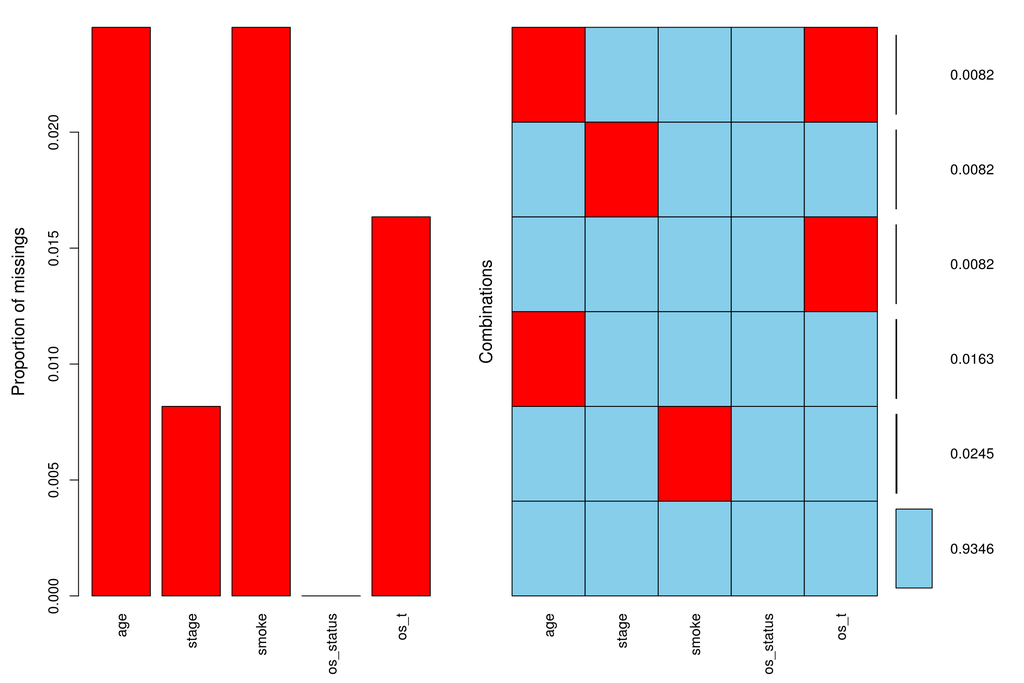

```r
lusc_clinical %>% dplyr::select(age, stage = ajcc_pathologic_tumor_stage,
    smoke = tobacco_smoking_history_indicator, os_status, os_t = os_months) %>%
    VIM::aggr(prop = T, labels = colnames(.), numbers = TRUE)
```

Finally, let’s observe the outcome as we did in the COAD dataset:

```
## Call: survfit(formula = Surv(os_months, os_status) ~ 1, data = lusc_clinical %>%
##     dplyr::mutate(os_months = as.numeric(os_months), os_status = os_status ==
##         "DECEASED"))
##
##    6 observations deleted due to missingness
##       n  events  median 0.95LCL 0.95UCL
##   361.0   154.0    55.7    43.9    71.0
```

```
## Call: survfit(formula = Surv(dfs_months, dfs_status) ~ 1, data = lusc_clinical %>%
##     dplyr::mutate(dfs_months = as.numeric(dfs_months), dfs_status = dfs_status ==
##         "Recurred/Progressed"))
##
##    87 observations deleted due to missingness
##       n  events  median 0.95LCL 0.95UCL
##   280.0   107.0    58.4    49.4    75.7
```

```
## Call: survfit(formula = Surv(os_months, os_status) ~ dfs_status, data = lusc_clinical %>%
##     dplyr::mutate(os_months = as.numeric(os_months), os_status = os_status ==
##         "DECEASED", dfs_status = ifelse(is.na(dfs_status), "DiseaseFree",
##         dfs_status)))
##
##    6 observations deleted due to missingness
##                                  n events median 0.95LCL 0.95UCL
## dfs_status=DiseaseFree         255     82   73.1    60.5   126.1
## dfs_status=Recurred/Progressed 106     72   32.9    25.3    54.4
```

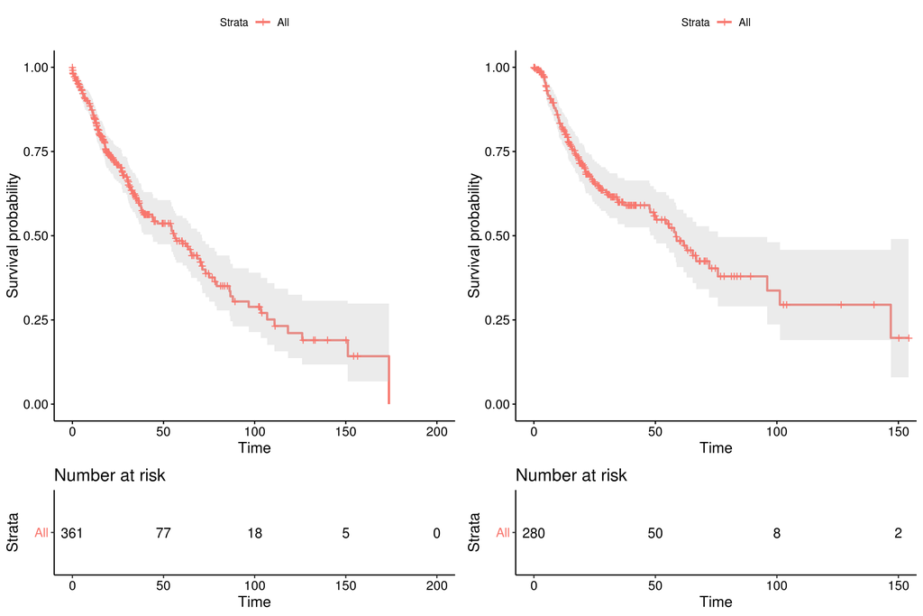

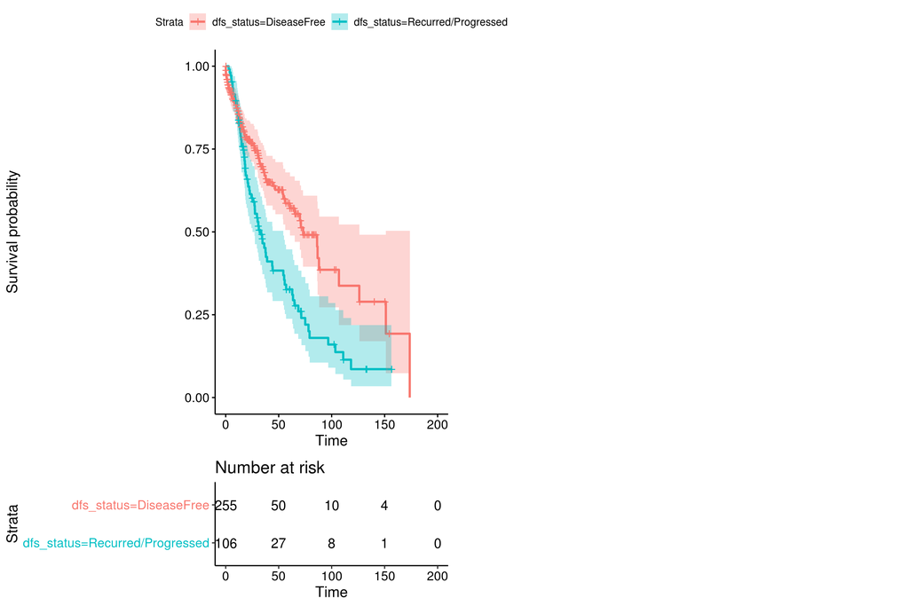